# 43. 項目反応理論 (IRT) 等化

Masahiko Asano

2025-04-27

- このセクションで使っている packages

```r
library(DT)
library(plyr)
library(reactable)
library(tidyverse)
library(glpkAPI)
library(psych)
library(irtoys)
library(ltm)
library(plink)
```

# 7. IRT による等化

#### 等化 (equating) とは

- 2 つの尺度について、どちらか一方の尺度に、他方の尺度の0点の位置や目盛の幅を与えること  
  → どちらか一方の尺度に他方の尺度の「原点」と「単位」を与えること
- 2 つの尺度「華氏温度 $F$」と「摂氏温度 $C$」に関す変換式を求めること

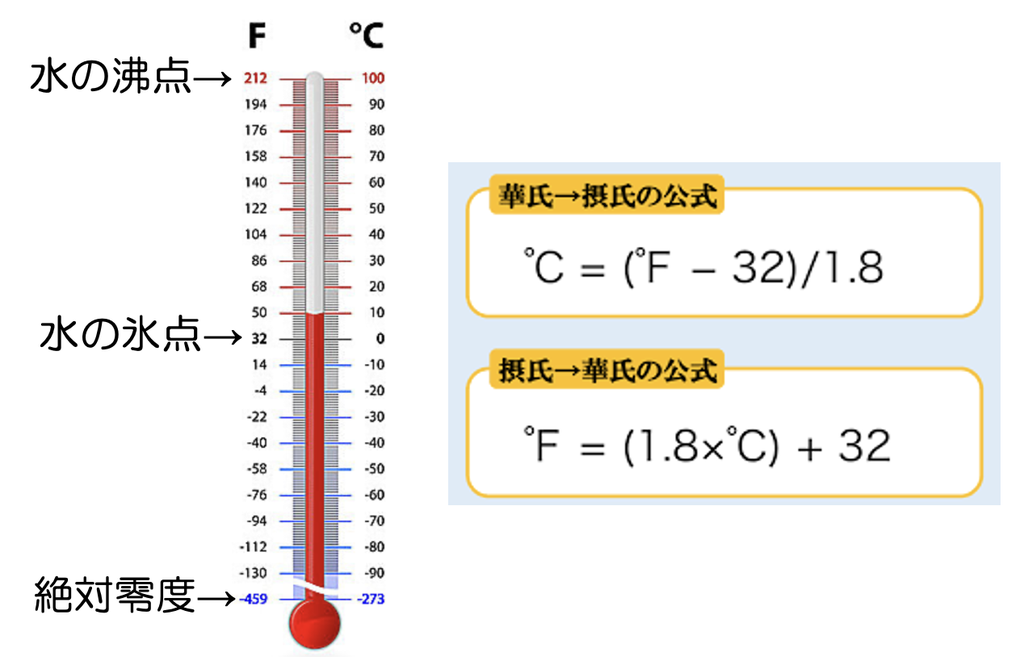

## 7.1 線形変換

IRT を使うと次の 2 つのことが可能になる ・テストに用いた**項目**に依存せずに、項目パラメタを推定できる  
→ **異なる問題**から構成されるテスト結果を互いに比較できる

・テストを受けた**受験者集団**に依存せずに、項目パラメタを推定できる  
→ **異なる集団**から得られたテスト結果を互いに比較できる

- 毎年4月に、新入生を対象として実力テストを実施していると仮定
- 昨年実施したテストが X、今年実施したテストが Y
- 昨年の実職テストを IRT の 2 パラメーター・ロジスティック・モデルで分析  
  → 分析から得られた「困難度のものさし」 = 尺度$\theta_x$
- テスト X に出題した項目：$x1, x2, ...., x10$

##### テスト X から得られた困難度の尺度$\theta_x$

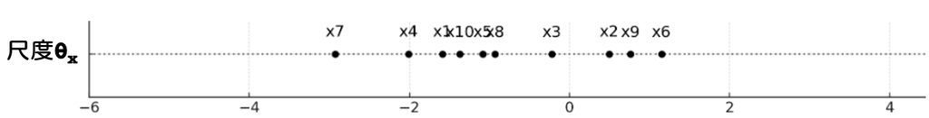

- 今年の実職テストを IRT の 2 パラメーター・ロジスティック・モデルで分析  
  → 分析から得られた「困難度のものさし」 = 尺度$\theta_y$
- テスト X に出題した項目：$y1, y2, ...., y10$

##### テスト y から得られた困難度の尺度$\theta_y$

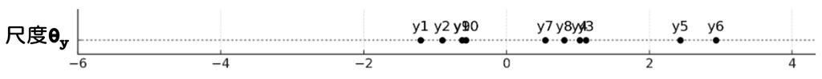

- 尺度$\theta_x$ と 尺度$\theta_y$ を比較すると  
  → 尺度$\theta_y$ の方が困難度が大きいから、問題が難しいのでは？  
  → しかし、必ずしもそうとはいえない

##### その理由 → 尺度$\theta_x$ と 尺度$\theta_y$ は目盛は同じだが、同じ意味ではないから

- 例えば、尺度$\theta_x$ の x2 と尺度$\theta_y$ の y7 はそれぞれの目盛りでほとんど同じ位置にある
- しかし、x2 と y7 は同じくらい難しい項目だとはいえない

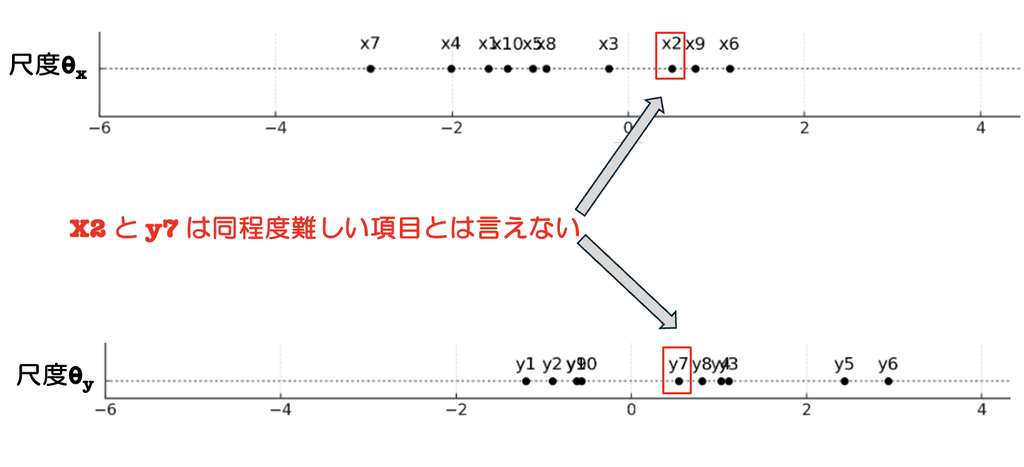

- 2 つのテスト結果を同一の尺度に統一すれば  
  → 2つの異なる集団から得られたテスト結果を互いに比較できる  
  → 線形変換

#### 線形変換

- 変換したいものに（ここでは $\theta_y$)、ある定数をかけたり足したりして、他の尺度（ここでは $\theta_x$）に変換すること

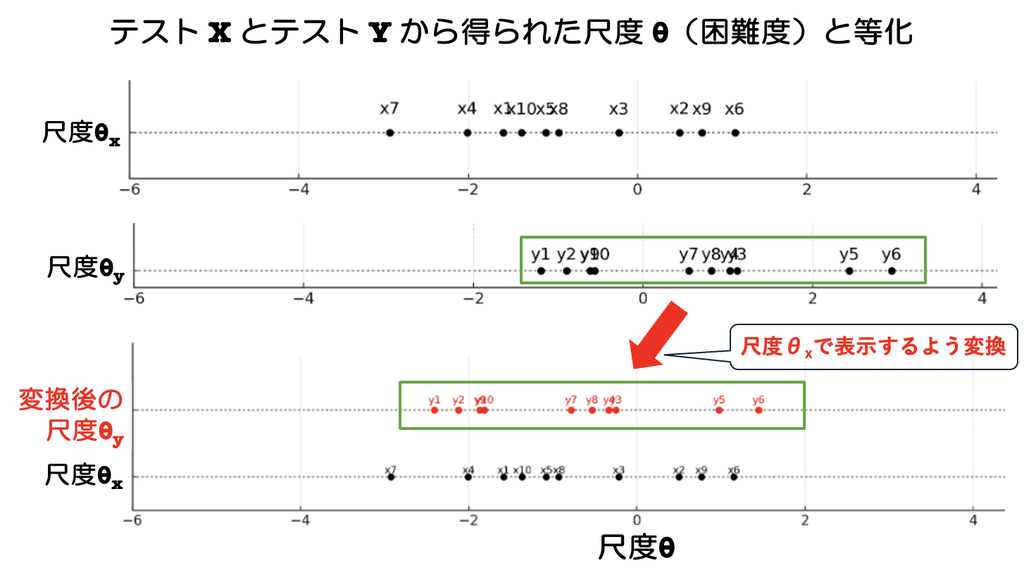

- 線形変換することで、尺度$\theta_y$上に並べた項目 ($y1,...,y10$) を尺度$\theta_x$ 上に並べることができる  
  → 等化
- テスト X を受験した学力$\theta_x$ の人も、テスト Y を受験した学力$\theta_y$ の人も、どちらも学力$\theta_x$で表すことができるようになった

#### 共通尺度とは

- ここでは 学力$\theta_x$ のこと
- 等化された項目の困難度や受験者の学力$\theta$を表す尺度のこと

## 7.2 等化デザイン

- 等化をするためには、等化するテスト間に共通の情報が必要
- 共通の情報を何に使うかによって、2 つの等化デザインがある

| **等化デザインの種類** | **共通するもの** |
| --- | --- |
| 共通項目デザイン | 項目 |
| 共通受験者デザイン | 受験者 |

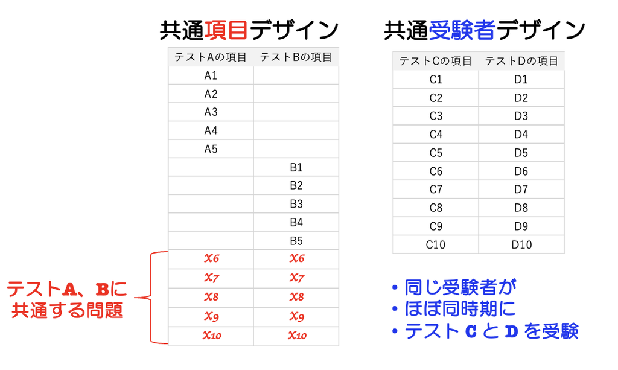

### 7.3.1 共通**項目**デザイン

- 共通した項目のパラメーターの値を利用して等化する方法
- 等化するテスト間で共通の項目 X6,…,x10 を出題する
- テストAとテストBに共通する5つの項目 **(x6,…, x10)** を出題
- テストAでは A1,…,A5 と **x6,…, x10** の計10の項目を出題
- テストBでは B1,…,B5 と **x6,…, x10** の計10の項目を出題
- テストAとテストBを異なる受験者集団に対して実施する
- テスト結果を IRTの 2パラメーター・ロジスティック・モデルを使って分析
- テストAを IRT分析して得られた「ものさし」・・・尺度$\theta_A$
- テストBを IRT分析して得られた「ものさし」・・・尺度$\theta_B$
- テストAに出題した項目を、困難度の値によって尺度$\theta_A$ に並べると

#### テスト B をテスト A に等化する

- 尺度$\theta_B$ で表された困難度の値を、尺度$\theta_A$ で表すこと

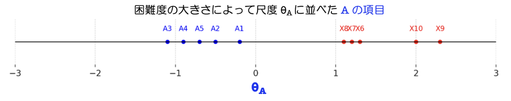

- テストAとテストBに共通する5つの項目**x6,…, x10**よりもテストAでのみ出題された5つの項目**(A1,…,A5)**の方が簡単

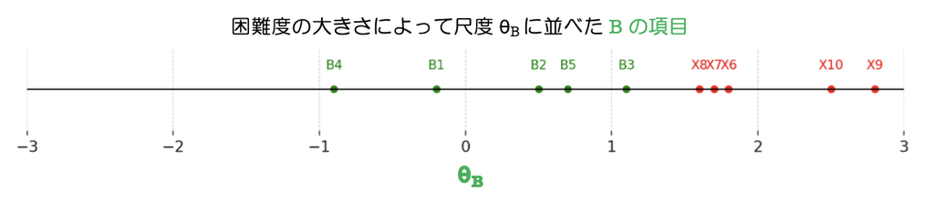

- テストAとテストBに共通する5つの項目**x6,…, x10**よりもテストBでのみ出題された5つの項目**(B1,…,B5)**の方が簡単

#### 以下の 2 つの困難度の値は異なる

・尺度$\theta_A$ で表された x6〜x10 の困難度の値  
・尺度$\theta_B$ で表された x6〜x10 の困難度の値  
・同じ項目（例えば x10）であれば、項目の「困難度の程度」を表すという点では同じ意味

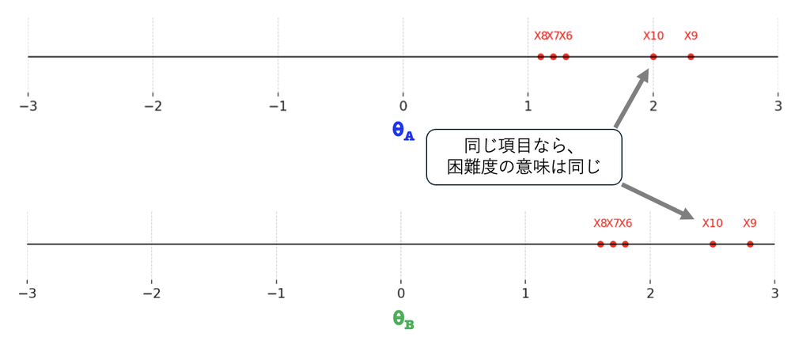

→ 同じ温度でも摂氏と華氏とでは数値が異なることと同様

$$華氏　＝　1.8×摂氏+32$$

##### 「テストBをテストAに等化する方法」は「摂氏を華氏に変換する方法」と似ている

困難度の変換

・摂氏を華氏に変換するのと同様、「尺度$\theta_B$ で表された困難度」は次の式で「尺度$\theta_A$ で表された困難度」に変換できる

$$尺度\theta_A で表された困難度＝$$
$$（定数1）×尺度\theta_Bで表された困難度＋（定数2）$$

- （定数1）と（定数2）を計算する方法・・・Mean & Sigma法
- （定数1）と（定数2）が計算できれば  
  → テストBで出題された項目B1,…, B10の困難度を、尺度$\theta_A$ で表せる
- **項目B1〜B5 の困難度の値**を**変換** → **テストAの尺度$\theta_A$ 上に配置**

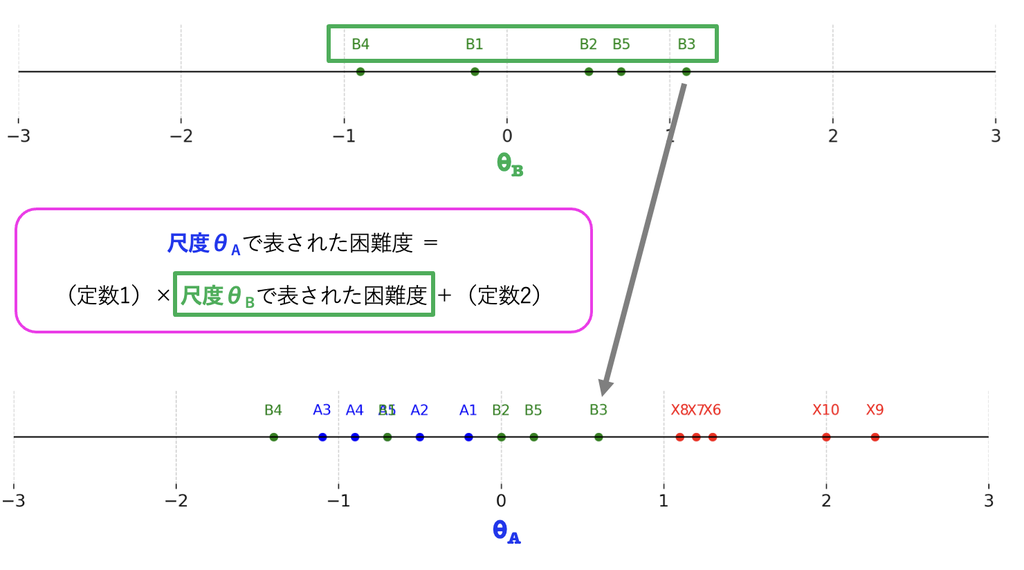

識別力の変換

- 識別力は（定数1）を使って次のように変換できる

$$尺度\theta_A で表された識別力＝$$
$$尺度\theta_Bで表された識別力÷（定数1）$$

受験者の学力$\theta$

- テストAの受験者の学力$\theta$・・・もともと尺度$\theta_A$ で表す
- テストBの受験者の学力$\theta$・・・等化されたテストBの項目パラメーターで表された項目特性を使って学力$\theta$ を推定する  
  → テストAとテストBの受験者の学力$\theta$はどちらも尺度$\theta_A$ で表すことができる → テストBの受験者の学力$\theta$が等化された

### 7.3.2 共通**受験者**デザイン

- 共通した受験者のパラメーターの値を利用して等化する方法
- テストCとテストDには、全く別の項目が出題
- テストCでは C1,…,C10の10個の項目を出題
- テストDでは D1,…,D10の10個の項目を出題
- 共通の受験者が、テストCとテストDをほぼ同時に受験する

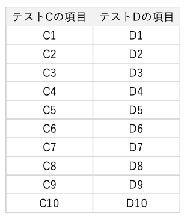

- テストCの結果をIRT分析・・・尺度$\theta_C$を得る
- テストDの結果をIRT分析・・・尺度$\theta_D$を得る
- 二つのものさし（尺度$\theta_C$ と尺度$\theta_D$）は異なる  
  → 同じ受験者であっても、それぞれのものさしで表される学力$\theta$ の値は異なる
- **しかし、同じ受験者の学力$\theta$なら、値は異なっても、同じ学力を意味する**  
  → 下の式を使って、学力を変換できる

$$尺度\theta_Cでの学力\theta=$$
$$（定数1）×尺度 \theta_D で表された学力
\theta ＋（定数2）$$

- IRTに使うテストでは、必ず過去問題が使われるわけではない
- テストに出題される問題が全て新規作成でも（＝等化されていなくても）  
  → 共通**受験者**デザインを使えば、IRTによる等化は可能

#### 異なる2つの全国テストを受けた受験生の学力比較

- 例えば、4月に実施した全国テスト1と10月に実施した全国テスト2の受験生の学力を比較することを考える

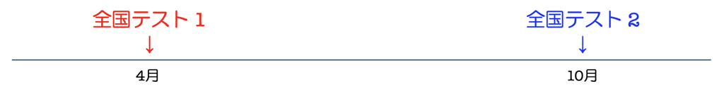

| **比較方法** | **内容** |
| --- | --- |
| ナイーブな直接比較 | 全国テスト1と全国テスト2の得点をそのまま比較 |
| 等化を経た比較 | 等化された共通尺度θxを使って全国テストを比較 |

##### ナイーブな直接比較の問題点

- 全国テスト1と2は異なるテスト  
  → 得点の意味が異なる（例：50点が同じ学力を示すとは限らない）
- 同じ尺度で測られていないテストを比べると  
  → 学力の成長や差異を正しく把握できない
- 例えるなら、4月の体重をkg単位で測り、10月の体重をポンド単位で測り
- 変化をそのまま比較するようなもの（単位が違う）

##### 解決策：

- 2つの全国テストとほぼ同時期に、等化済みの共通尺度をもつ2つのテストを受ければ可能

| **集団** | **実施時期** | **実施テスト** | **等化済みの共通尺度** |
| --- | --- | --- | --- |
| 集団A | 4月 | **全国テスト1**、**テスト1** | **θx（テスト1とテスト2）** |
| 集団B | 10月 | **全国テスト2**、**テスト2** | **θx（テスト1とテスト2）** |

- 全国テスト1と全国テスト2の直接の等化情報はない
- しかし、テスト1とテスト2が共通尺度θxで等化されていれば  
  → テスト1の得点もテスト2の得点もθxという同じ尺度で表現可能
- 全国テスト1を受けた集団Aはテスト1も受けている  
  → 全国テスト1の得点をθxに変換できる  
  全国テスト2を受けた集団Bはテスト2も受けている  
  → 全国テスト2の得点をθxに変換できる

##### 結果として

→ 全国テスト1（4月）と全国テスト2（10月）の得点を、共通尺度θxで等化可能  
→ 学力の**時点間比較（成長の可視化）**ができる

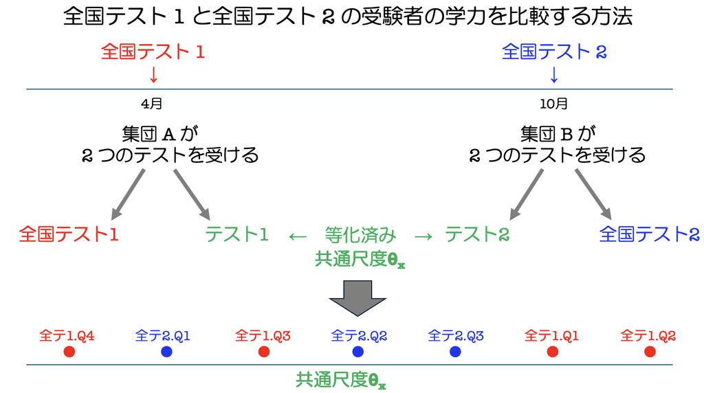

#### テスト1とテスト2による等化を用いた比較の利点

##### 共通尺度 θx による比較ができる

- テスト1とテスト2でIRT等化済み  
  → 全国テスト1・2の得点を同じθx上にマッピングできる

##### テストの難易度や尺度の違いを補正できる

- テスト間の構成や困難度の違いをIRTモデルで補正できる  
  → 純粋に学力の違い・成長を測定可能

##### 項目反応理論による学力推定ができる

- 単なる合計得点ではなく、項目特性（識別力・困難度）を考慮したθ推定ができる
- 例：難しい問題に正答した生徒は、同じ得点でもより高いθと評価される

##### 時間軸をまたいだ比較が可能

- 「4月の全国テスト1」と「10月の全国テスト2」でも、θxが共通なので成長や差異を妥当な形で比較可能

まとめ  
・「全国テスト1と2だけを受けた生徒」の得点比較は、テスト構造や尺度の違いの影響を受けやすく、信頼性に欠ける  
・テスト1・2を介してIRT等化された尺度θxを使えば、「異なる時点・異なるテスト」の結果も、共通の学力指標で直接比較できる

## 7.3 等化の条件

等化の条件  
1. 各尺度が同一の構成概念を測定している。  
2. 変換に対称性がある。  
3. 2つの尺度の信頼性が等しい。  
4. θによる素点の条件付き分布が両尺度で等しい。  
5. どの集団において等化を行っても変換は不変。  
（出典：加藤建太郎他『Rによる項目反応理論』p.257.